# Analyse univariee du metabolome

# Chargement des librairies

```r
library(knitr)

library(multcomp)

library(ggplot2)

library(ggpubr)
```

# Import des donnees

```r
table1<-read.table("C:/Users/Gardette/Documents/APT/2A/Big Data/Metabolome/metabolome_Ath.csv", sep=";", dec=".", header=T,row.names=1)
```

# Preparation des donnees

## Transformation centree-reduite des valeurs individuelles du tableau

```r
table1<-scale(table1)
```

## Ajout d’un facteur de groupe pour definir les echantillons

```r
temperature<-factor(rep(c("Low","Medium","Elevated"),each=3),levels=c("Low","Medium","Elevated"))

table2<-cbind.data.frame(temperature,table1)
```

# Representation graphique des variables

```r
# fichier pdf ecrit dans le repertoire de travail

pdf("boxplot_proteome_724_proteines.pdf")

for(i in 2:ncol(table2)) {

  varname <- colnames(table2[i])

  g <-
    ggplot(table2, aes(fill = temperature)) +
    geom_boxplot(aes_string(x = temperature, y = table2[, i])) +
    labs(title = varname, x = "temperature conditions", y = "protein abundance") +
    theme(plot.title = element_text(
      colour = "red",
      size = 30,
      hjust = 0.5
    )) +
    theme(axis.title.x = element_text(colour = "black", size = 15)) +
    theme(axis.title.y = element_text(colour = "black", size = 15)) +
    theme(axis.text.x = element_text(colour = "black", size = 15)) +
    theme(axis.text.y = element_text(colour = "black", size = 10)) +
    scale_fill_manual(
      breaks = c("Low", "Medium", "Elevated"),
      values = c("lightblue", "lightgreen", "orange")
    )

  print(g)

}

dev.off()
```

## Exemple de boxplot

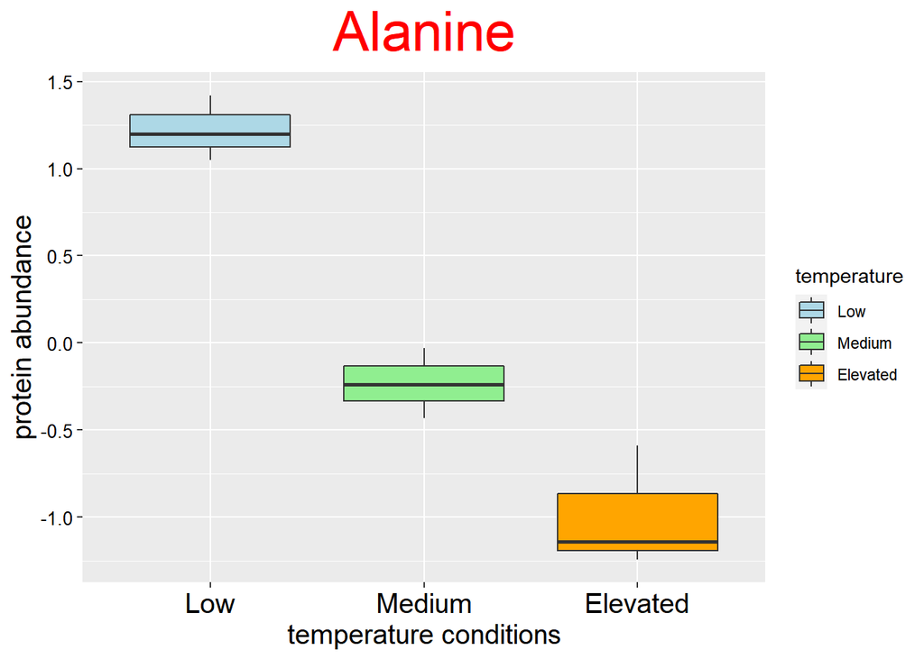

```r
i=2

varname<-colnames(table2[i])

g <- ggplot(table2, aes(fill = temperature)) +
  geom_boxplot(aes_string(x = temperature, y = table2[, i])) +
  labs(title = varname, x = "temperature conditions", y = "protein abundance") +
  theme(plot.title = element_text(
    colour = "red",
    size = 30,
    hjust = 0.5
  )) +
  theme(axis.title.x = element_text(colour = "black", size = 15)) +
  theme(axis.title.y = element_text(colour = "black", size = 15)) +
  theme(axis.text.x = element_text(colour = "black", size = 15)) +
  theme(axis.text.y = element_text(colour = "black", size = 10)) +
  scale_fill_manual(
    breaks = c("Low", "Medium", "Elevated"),
    values = c("lightblue", "lightgreen", "orange")
  )

print(g)
```

# Analyse de variance sur chaque variable

## Anova

```r
pvalue_anova<- c()

for(i in 2:ncol(table2)) {

  res_anova <- aov(table2[,i] ~ temperature, data = table2)
  paramANOVA <- summary(res_anova)
  pvalue_anova[i] <- paramANOVA[[1]][, 5][1]

}

names(pvalue_anova) <- colnames(table2)

kable(pvalue_anova[2:11])
```

|  | x |
| --- | --- |
| Alanine | 0.0001232 |
| Arginine | 0.0119029 |
| Asparagine | 0.0017377 |
| Aspartate | 0.0003643 |
| Cystein | 0.0396905 |
| Gaba | 0.1903599 |
| Glutamine | 0.8133718 |
| Glutamate | 0.0001056 |
| Glycine | 0.0433642 |
| Isoleucine | 0.0026289 |

## Distribution des p-values non corrigees

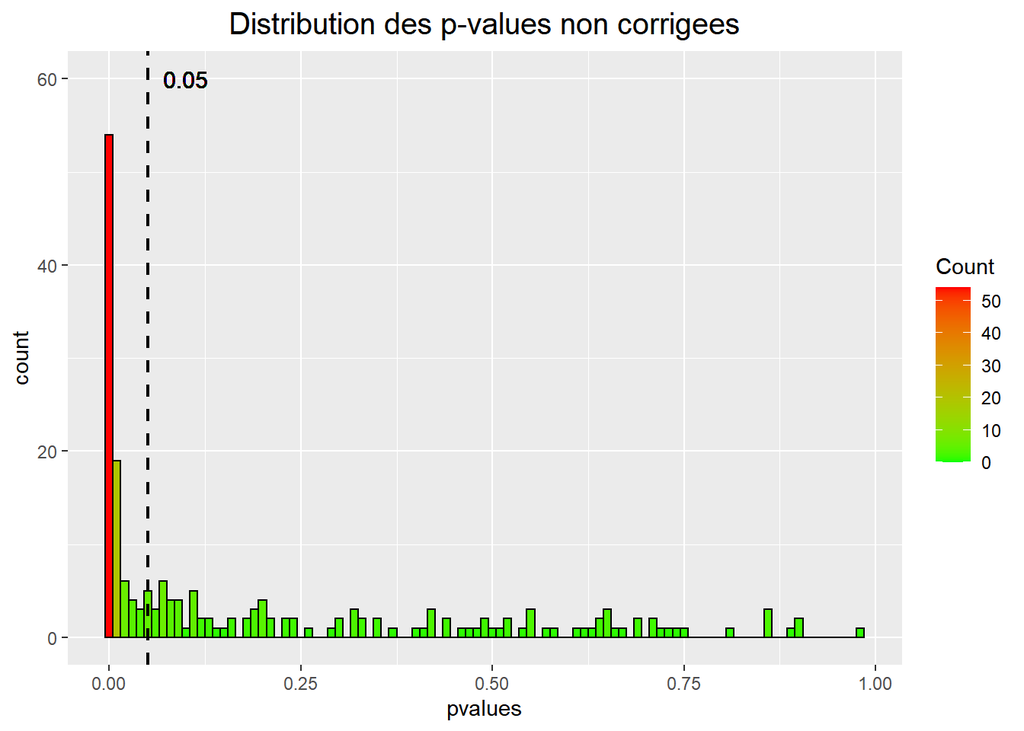

```r
df_pvalue <-
  data.frame(names = names(pvalue_anova), pvalues = pvalue_anova)

g <- ggplot(df_pvalue, aes(x = pvalues)) +
  geom_histogram(binwidth = 0.01, color = "black", aes(fill = ..count..)) +
  geom_vline(
    aes(xintercept = 0.05),
    colour = "black",
    linetype = "dashed",
    size = 0.75
  ) +
  geom_text(aes(x = 0.1, label = "0.05", y = 60),
            colour = "black",
            size = 4) +
  scale_fill_gradient("Count", low = "green", high = "red") +
  labs(title = "Distribution des p-values non corrigees") +
  theme(plot.title = element_text(
    colour = "black",
    size = 15,
    hjust = 0.5
  ))

print(g)
```

## Nombre de variables présentant des différences significatives

```r
liste1 <- na.omit(pvalue_anova[pvalue_anova<0.05])
length(liste1)
```

[1] 89

```r
liste2 <- na.omit(pvalue_anova[pvalue_anova<0.01])
length(liste2)
```

[1] 70

```r
liste3 <- na.omit(pvalue_anova[pvalue_anova<0.001])
length(liste3)
```

[1] 40

```r
names(liste3)
```

[1] “Alanine” “Aspartate” “Glutamate” “Threonine” “Tryptophan” “gamma.Tocopherol” “Eicosanoate” “Quercitrin”  
[9] “X4MTB” “X5MTP” “X6MTH” “X7MTH” “X8MTO” “BenzoylGlucosinolate.3Breakdown” “BenzoylX.Glucosinolate.3” “Nonanenitrile.9.methylthio”  
[17] “Sulfite” “U2609.4.361” “U3122.4.202.I3M.” “UGlucosinolate140.1” “Succinate” “Allantoin” “beta.indole.3.acetonitrile” “Digalactosylglycerol”  
[25] “Galactinol” “Rhamnose” “U1270.1.240” “U1408.4.298” “U1718.0.157” “U2473.361” “U2529.8.361” “U2692.9.361”  
[33] “U2798.377” “U2839.3.312” “U2882.5.297” “U2924.3.361” “U3080.7.361” “U3218.5.297” “U3279.7.361” “U3415.9.498”

## Correction des p-values pour tests multiples

```r
# utilisation d'une méthode FDR

pvalue_anova_adj <- p.adjust(pvalue_anova, method = "fdr")

kable(pvalue_anova_adj[2:11])
```

|  | x |
| --- | --- |
| Alanine | 0.0009334 |
| Arginine | 0.0325677 |
| Asparagine | 0.0074419 |
| Aspartate | 0.0023152 |
| Cystein | 0.0930837 |
| Gaba | 0.2976262 |
| Glutamine | 0.8433381 |
| Glutamate | 0.0009334 |
| Glycine | 0.0993344 |
| Isoleucine | 0.0105694 |

## Distribution des p-values corrigees

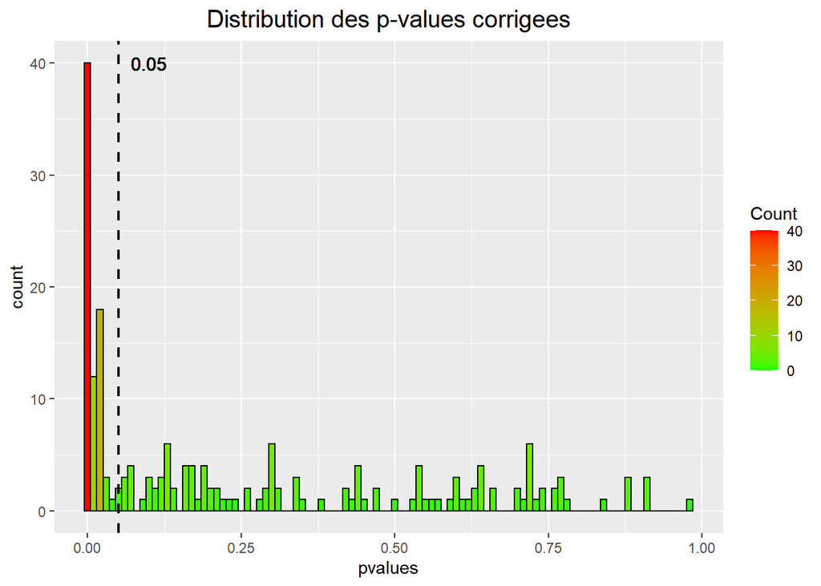

```r
df_pvalue_adj <-
  data.frame(names = names(pvalue_anova_adj), pvalues = pvalue_anova_adj)

g <- ggplot(df_pvalue_adj, aes(x = pvalues)) +
  geom_histogram(binwidth = 0.01, color = "black", aes(fill = ..count..)) +
  geom_vline(
    aes(xintercept = 0.05),
    colour = "black",
    linetype = "dashed",
    size = 0.75
  ) +
  geom_text(aes(x = 0.1, label = "0.05", y = 40),
            colour = "black",
            size = 4) +
  scale_fill_gradient("Count", low = "green", high = "red") +
  labs(title = "Distribution des p-values corrigees") +
  theme(plot.title = element_text(
    colour = "black",
    size = 15,
    hjust = 0.5
  ))

print(g)
```

## Application d’un filtre sur les p-values corrigees

```r
liste4 <- na.omit(pvalue_anova_adj[pvalue_anova_adj<0.05])

length(liste4)
```

[1] 75

```r
names(liste4)
```

[1] “Alanine” “Arginine” “Asparagine” “Aspartate” “Glutamate” “Isoleucine” “Serine” “Threonine”  
[9] “Tryptophan” “gamma.Tocopherol” “Eicosanoate” “Heptadecanoate” “Quercitrin” “X4MTB” “X5MTP” “X6MTH”  
[17] “X7MTH” “X8MTO” “BenzoylGlucosinolate.3Breakdown” “BenzoylX.Glucosinolate.3” “Nonanenitrile.9.methylthio” “Sulfite” “U2609.4.361” “U3122.4.202.I3M.”  
[25] “UGlucosinolate140.1” “UGlucosinolatebreakdown140.4” “H2SO4” “Fumarate” “Galactonate” “Gluconate” “Glycerate” “Pentonate.4”  
[33] “Sinapinate.cis” “Succinate” “Allantoin” “beta.indole.3.acetonitrile” “Xylitol” “Anhydroglucose” “Digalactosylglycerol” “Galactinol”  
[41] “Galactose” “Raffinose” “Rhamnose” “Sucrose” “U1093.6.147” “U1154.3.156” “U1270.1.240” “U1393.172”  
[49] “U1408.4.298” “U1559.4.217” “U1628.9.233” “U1718.0.157” “U1983.0.217.1” “U2012.7.361” “U2053.6.321.1” “U2170.6.361”  
[57] “U2371.1.361” “U2473.361” “U2513.2.296.1” “U2529.8.361” “U2688.5.333” “U2692.9.361” “U2756.4.271” “U2798.377”  
[65] “U2828.8.361” “U2839.3.312” “U2857.8.342” “U2882.5.297” “U2924.3.361” “U2929.1.297” “U3080.7.361” “U3218.5.297”  
[73] “U3279.7.361” “U3415.9.498” “U3701.368”

# Comparaisons multiples : détailler les résultats de l’anova

## Realisation d’une comparaison entre groupe pris 2 à 2 : p-values

```r
tabmult = NULL

for (i in 2:ncol(table2)) {

  aov <- aov(table2[, i] ~ temperature, data = table2)
  multcomp <- TukeyHSD(aov)
  tabmult <- cbind(tabmult, multcomp$temperature [, 4])

}


vecteurNA<-rep("NA",nrow(tabmult))

tabmult2<-cbind.data.frame(vecteurNA,tabmult)

colnames(tabmult2)<-colnames(table2)

kable(tabmult2[,2:8])
```

|  | Alanine | Arginine | Asparagine | Aspartate | Cystein | Gaba | Glutamine |
| --- | --- | --- | --- | --- | --- | --- | --- |
| Medium-Low | 0.0010902 | 0.0394209 | 0.0271137 | 0.0022338 | 0.0622529 | 0.6804515 | 0.8875584 |
| Elevated-Low | 0.0001063 | 0.0118130 | 0.0013942 | 0.0003344 | 0.0542718 | 0.4799684 | 0.9862079 |
| Elevated-Medium | 0.0264168 | 0.5723296 | 0.0516834 | 0.0964456 | 0.9933176 | 0.1712687 | 0.8103808 |

## Graphes de Tukey : boxplots avec Compact Letter Display (cld)

```r
# fichier pdf ecrit dans le repertoire de travail

pdf("graphes_Tukey_proteome_724_proteines.pdf")

  for (i in 2:ncol(table2)) {

    varname <- colnames(table2[i])

    res_anova <- aov(table2[, i] ~ temperature, data = table2)
    tuk <- glht(res_anova, linfct = mcp(temperature = "Tukey"))

    CLD <- cld(tuk, level = 0.05)
    CLD <-
      data.frame(
        temperature = names(CLD$mcletters$Letters),
        lettres = CLD$mcletters$Letters
      )

    g <- ggplot(table2, aes(fill = temperature)) +
      geom_boxplot(aes_string(x = table2$temperature, y = table2[, i])) +

      labs(title = varname,
           x = "temperature conditions",
           y = "protein abondance") +

      theme_grey() +

      theme(plot.title = element_text(
        colour = "red",
        size = 20,
        hjust = 0.5
      )) +

      theme(axis.title.x = element_text(colour = "black", size = 15)) +
      theme(axis.title.y = element_text(colour = "black", size = 15)) +
      theme(axis.text.x = element_text(
        angle = 0,
        colour = "black",
        size = 15
      )) +
      theme(axis.text.y = element_text(colour = "black", size = 10)) +

      geom_text(
        data = CLD,
        aes(
          x = temperature,
          label = lettres,
          y = max(table2[, i]) + 0.1
        ),
        colour = "black",
        size = 6
      ) +

      scale_fill_manual(
        breaks = c("Low","Medium","Elevated"),
        values = c("lightblue", "lightgreen", "orange")
      )

    print(g)

  }

dev.off()
```

## Exemple pour une variable

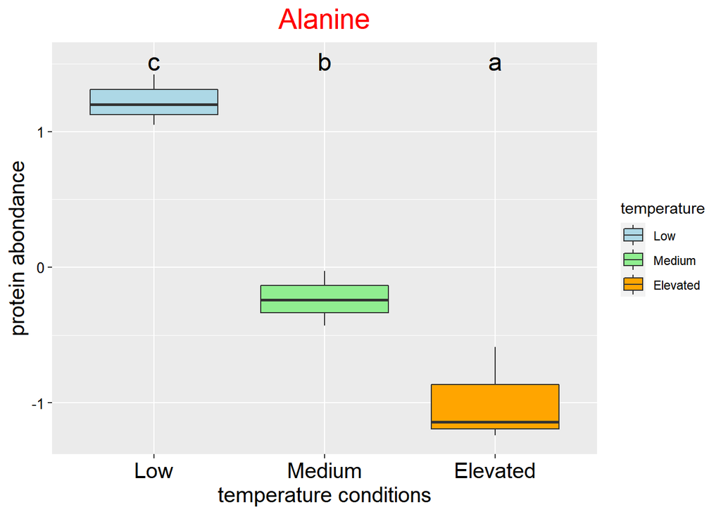

```r
i=2

varname <- colnames(table2[i])

res_anova <- aov(table2[, i] ~ temperature, data = table2)
tuk <- glht(res_anova, linfct = mcp(temperature = "Tukey"))

CLD <- cld(tuk, level = 0.05)
CLD <-
  data.frame(
    temperature = names(CLD$mcletters$Letters),
    lettres = CLD$mcletters$Letters
  )

g <- ggplot(table2, aes(fill = temperature)) +
  geom_boxplot(aes_string(x = table2$temperature, y = table2[, i])) +

  labs(title = varname,
       x = "temperature conditions",
       y = "protein abondance") +

  theme_grey() +

  theme(plot.title = element_text(
    colour = "red",
    size = 20,
    hjust = 0.5
  )) +

  theme(axis.title.x = element_text(colour = "black", size = 15)) +
  theme(axis.title.y = element_text(colour = "black", size = 15)) +
  theme(axis.text.x = element_text(
    angle = 0,
    colour = "black",
    size = 15
  )) +
  theme(axis.text.y = element_text(colour = "black", size = 10)) +

  geom_text(
    data = CLD,
    aes(
      x = temperature,
      label = lettres,
      y = max(table2[, i]) + 0.1
    ),
    colour = "black",
    size = 6
  ) +

  scale_fill_manual(
    breaks = c("Low","Medium","Elevated"),
    values = c("lightblue", "lightgreen", "orange")
  )

print(g)
```

## Recuperation de la matrice de Tukey des cld

```r
varname <- c()

matrice_tuk <- matrix()

for (i in 2:ncol(table2)) {

  varname <- colnames(table2[i])
  aov <- aov(table2[, i] ~ temperature, data = table2)
  tuk <- glht(aov, linfct = mcp(temperature = "Tukey"))
  out_cld <- cld(tuk, level = 0.05)
  matrice_tuk <-
    cbind.data.frame(matrice_tuk, out_cld$mcletters$Letters)

}

colnames(matrice_tuk) <- colnames(table2)

kable(matrice_tuk[,2:8])
```

|  | Alanine | Arginine | Asparagine | Aspartate | Cystein | Gaba | Glutamine |
| --- | --- | --- | --- | --- | --- | --- | --- |
| Low | c | b | a | a | a | a | a |
| Medium | b | a | b | b | a | a | a |
| Elevated | a | a | b | b | a | a | a |

## Recherche de variables presentant des profils de variation particuliers

```r
# exemple de filtrage de la matrice de Tukey contenant les cld

# ici recherche des profils "a","a","b" presentant un maximum d'abondance en condition "Elevated"

matrice_tuk_ftr<-matrice_tuk[,which(matrice_tuk[1,]=="a" & matrice_tuk[2,]=="a" & matrice_tuk[3,]=="b")]


# nb de variables presentant ce profil

dim(matrice_tuk_ftr)
```

[1] 3 10

```r
colnames(matrice_tuk_ftr)
```

[1] “UGlucosinolate140.1” “U1393.172” “U1628.9.233” “U2053.6.321.1” “U2371.1.361” “U2473.361” “U2756.4.271” “U2828.8.361” “U2857.8.342” “U2924.3.361”

```r
kable(matrice_tuk_ftr[1:8])
```

|  | UGlucosinolate140.1 | U1393.172 | U1628.9.233 | U2053.6.321.1 | U2371.1.361 | U2473.361 | U2756.4.271 | U2828.8.361 |
| --- | --- | --- | --- | --- | --- | --- | --- | --- |
| Low | a | a | a | a | a | a | a | a |
| Medium | a | a | a | a | a | a | a | a |
| Elevated | b | b | b | b | b | b | b | b |

# Création du tableau de résultats final

```r
# calcul des moyennes d'abondance par temperature

matrice_moy <-
  aggregate(table2[, 2:ncol(table2)], by = list(table2$temperature), FUN =
              mean)

colnames(matrice_moy) <- colnames(table2)

row.names(matrice_moy) <-
  c("moyenne Low", "moyenne Medium", "moyenne Elevated")

table4 <-
  rbind.data.frame(
    round(matrice_moy[, -1], 3),
    "pvalue_anova" = round(pvalue_anova[-1], 3),
    "pvalue_anova_adj" = round(pvalue_anova_adj[-1], 3),
    round(tabmult2[, -1], 3),
    matrice_tuk[, -1]
  )

kable(table4[,1:8])
```

|  | Alanine | Arginine | Asparagine | Aspartate | Cystein | Gaba | Glutamine | Glutamate |
| --- | --- | --- | --- | --- | --- | --- | --- | --- |
| moyenne Low | 1.224 | 1.139 | -1.111 | -1.23 | 1.082 | 0.087 | 0.094 | -1.3 |
| moyenne Medium | -0.233 | -0.331 | 0.058 | 0.295 | -0.51 | 0.705 | -0.334 | 0.593 |
| moyenne Elevated | -0.991 | -0.807 | 1.053 | 0.936 | -0.571 | -0.792 | 0.239 | 0.707 |
| pvalue_anova | 0 | 0.012 | 0.002 | 0 | 0.04 | 0.19 | 0.813 | 0 |
| pvalue_anova_adj | 0.001 | 0.033 | 0.007 | 0.002 | 0.093 | 0.298 | 0.843 | 0.001 |
| Medium-Low | 0.001 | 0.039 | 0.027 | 0.002 | 0.062 | 0.68 | 0.888 | 0 |
| Elevated-Low | 0 | 0.012 | 0.001 | 0 | 0.054 | 0.48 | 0.986 | 0 |
| Elevated-Medium | 0.026 | 0.572 | 0.052 | 0.096 | 0.993 | 0.171 | 0.81 | 0.848 |
| Low | c | b | a | a | a | a | a | a |
| Medium | b | a | b | b | a | a | a | b |
| Elevated | a | a | b | b | a | a | a | b |

```r
# export du tableau final contenant toutes les donnees

write.table(
  table4,
  "tableau_final_univariee_proteome.csv",
  dec = ".",
  sep = ";",
  append = F,
  row.names = T,
  col.names = NA
)
```